# Sprawozdanie 1

## Zadanie 2.

Treść:

Dopasuj model (lub modele) regresji liniowej wielorakiej przewidujący wartość zmiennej Sales. Model zbuduj w wybrany przez siebie sposób. Oceń jakość modelu i spełnienie założeń. Porównaj otrzymane modele z modelem regresji liniowej prostej.

Rozwiązanie:

Zacznijmy od przypomnienia sobie jak wygląda nasz zbiór danych

```r
carseats <- tibble::as.tibble(ISLR::Carseats)
carseats
```

| Sales | CompPrice | Income | Advertising | Population | Price | ShelveLoc | Age | Education | Urban | US |
| --- | --- | --- | --- | --- | --- | --- | --- | --- | --- | --- |
| 9.50 | 138 | 73 | 11 | 276 | 120 | Bad | 42 | 17 | Yes | Yes |
| 11.22 | 111 | 48 | 16 | 260 | 83 | Good | 65 | 10 | Yes | Yes |
| 10.06 | 113 | 35 | 10 | 269 | 80 | Medium | 59 | 12 | Yes | Yes |
| 7.40 | 117 | 100 | 4 | 466 | 97 | Medium | 55 | 14 | Yes | Yes |
| 4.15 | 141 | 64 | 3 | 340 | 128 | Bad | 38 | 13 | Yes | No |
| 10.81 | 124 | 113 | 13 | 501 | 72 | Bad | 78 | 16 | No | Yes |
| 6.63 | 115 | 105 | 0 | 45 | 108 | Medium | 71 | 15 | Yes | No |
| 11.85 | 136 | 81 | 15 | 425 | 120 | Good | 67 | 10 | Yes | Yes |
| 6.54 | 132 | 110 | 0 | 108 | 124 | Medium | 76 | 10 | No | No |
| 4.69 | 132 | 113 | 0 | 131 | 124 | Medium | 76 | 17 | No | Yes |

[output cut: 390 more lines]

Następnie ładujemy pakiet ‘caret’

```r
library(caret)
```

Na podstawie naszych danych Carseats stworzymy modele przewidujące wartość zmiennej Sales i porównamy je za pomocą skorygowanego $R^2$.

Zaczniemy od modelu, który będzie przewidywał sprzedaż fotelików samochodowych $sales$ na podstawie jego ceny $price$.

Dzielimy dane dotyczące sprzedaży na dwie części: jedną, którą wykorzystamy do nauczenia modelu ($75%$ danych), i drugą, którą zostawiamy na bok, aby przetestować, jak dobrze nasz model się nauczył ($25%$ danych)

```r
set.seed(123)
split <- createDataPartition(Carseats$Sales, p = 0.75, list = FALSE)
Carseats_train <- Carseats[split, ]
Carseats_test <- Carseats[-split, ]
```

```r
carseats_model <- lm(Sales ~ Price, data = Carseats_train)
summary(carseats_model)
```

```
##
## Call:
## lm(formula = Sales ~ Price, data = Carseats_train)
##
## Residuals:
##     Min      1Q  Median      3Q     Max
## -6.5379 -1.8548 -0.1159  1.6238  7.6375
##
## Coefficients:
##             Estimate Std. Error t value Pr(>|t|)
## (Intercept) 12.99210    0.74889  17.348  < 2e-16 ***
## Price       -0.04739    0.00634  -7.474 8.67e-13 ***
## ---
## Signif. codes:  0 '***' 0.001 '**' 0.01 '*' 0.05 '.' 0.1 ' ' 1
##
## Residual standard error: 2.587 on 299 degrees of freedom
## Multiple R-squared:  0.1574, Adjusted R-squared:  0.1546
## F-statistic: 55.86 on 1 and 299 DF,  p-value: 8.668e-13
```

Podsumujemy działanie modelu

```r
model_summary <- function(model, train_data, test_data, train_actual_values, test_actual_values) {

  train_predicted_values <- predict(model, newdata = train_data)
  test_predicted_values <- predict(model, newdata = test_data)

  train_residuals <- train_actual_values - train_predicted_values
  test_residuals <- test_actual_values - test_predicted_values

  train_RMSE <- sqrt(mean(train_residuals^2))
  test_RMSE <- sqrt(mean(test_residuals^2))

  train_MAE <- mean(abs(train_residuals))
  test_MAE <- mean(abs(test_residuals))

  train_MAPE <- mean(abs(train_residuals / train_actual_values)) * 100
  test_MAPE <- mean(abs(test_residuals / test_actual_values)) * 100
  cat("Charakterystyki 'train'\n")
  cat("RMSE wynosi:", train_RMSE, "\n")
  cat("MAE wynosi:", train_MAE, "\n")
  cat("MAPE wynosi:", train_MAPE, "%\n")

  cat("------------------------------------\n")

  cat("Charakterystyki 'test'\n")
  cat("RMSE wynosi:", test_RMSE, "\n")
  cat("MAE wynosi:", test_MAE, "\n")
  cat("MAPE wynosi:", test_MAPE, "%\n")
}


model_summary(carseats_model, Carseats_train, Carseats_test, Carseats_train$Sales, Carseats_test$Sales)
```

```
## Charakterystyki 'train'
## RMSE wynosi: 2.578627
## MAE wynosi: 2.066641
## MAPE wynosi: Inf %
## ------------------------------------
## Charakterystyki 'test'
## RMSE wynosi: 2.374233
## MAE wynosi: 1.985758
## MAPE wynosi: 41.2785 %
```

Wartości charakterystyk liczbowych modelu:

Treningowe $R^2$ wyniosło: $0.1574$

Poprawione $R^2$ wyniosło: $0.1546$

Wyniki sugerują, że istnieje pewna zależność między ceną a sprzedażą fotelików samochodowych, jednak cena nie tłumaczy w pełni zmienności sprzedaży. Spróbujemy poprawić jakość modelu.

Tworzymy kolejny model, z dodatkową zmienną $CompPrice$, aby poprawić jego działanie:

```r
carseats_model_2 <- lm(Sales ~ Price + CompPrice, data = Carseats_train)

summary(carseats_model_2)
```

```
##
## Call:
## lm(formula = Sales ~ Price + CompPrice, data = Carseats_train)
##
## Residuals:
##     Min      1Q  Median      3Q     Max
## -5.5005 -1.5972 -0.1665  1.4713  6.2277
##
## Coefficients:
##              Estimate Std. Error t value Pr(>|t|)
## (Intercept)  5.786579   1.043762   5.544 6.52e-08 ***
## Price       -0.084809   0.007014 -12.091  < 2e-16 ***
## CompPrice    0.092183   0.010284   8.963  < 2e-16 ***
## ---
## Signif. codes:  0 '***' 0.001 '**' 0.01 '*' 0.05 '.' 0.1 ' ' 1
##
## Residual standard error: 2.3 on 298 degrees of freedom
## Multiple R-squared:  0.3363, Adjusted R-squared:  0.3319
## F-statistic: 75.51 on 2 and 298 DF,  p-value: < 2.2e-16
```

Podsumujmy nasz model

```r
model_summary(carseats_model_2, Carseats_train, Carseats_test, Carseats_train$Sales, Carseats_test$Sales)
```

```
## Charakterystyki 'train'
## RMSE wynosi: 2.288512
## MAE wynosi: 1.84455
## MAPE wynosi: Inf %
## ------------------------------------
## Charakterystyki 'test'
## RMSE wynosi: 2.177831
## MAE wynosi: 1.832082
## MAPE wynosi: 36.1335 %
```

```r
carseats_model_3 <- lm(Sales ~ Price + Advertising, data = Carseats_train)
summary(carseats_model_3)
```

```
##
## Call:
## lm(formula = Sales ~ Price + Advertising, data = Carseats_train)
##
## Residuals:
##     Min      1Q  Median      3Q     Max
## -7.9512 -1.5102  0.0202  1.5114  6.6457
##
## Coefficients:
##              Estimate Std. Error t value Pr(>|t|)
## (Intercept) 12.250622   0.715250  17.128  < 2e-16 ***
## Price       -0.048736   0.005976  -8.156 9.77e-15 ***
## Advertising  0.132446   0.021191   6.250 1.42e-09 ***
## ---
## Signif. codes:  0 '***' 0.001 '**' 0.01 '*' 0.05 '.' 0.1 ' ' 1
##
## Residual standard error: 2.437 on 298 degrees of freedom
## Multiple R-squared:  0.2551, Adjusted R-squared:  0.2501
## F-statistic: 51.01 on 2 and 298 DF,  p-value: < 2.2e-16
```

```r
model_summary(carseats_model_3, Carseats_train, Carseats_test, Carseats_train$Sales, Carseats_test$Sales)
```

```
## Charakterystyki 'train'
## RMSE wynosi: 2.424606
## MAE wynosi: 1.901949
## MAPE wynosi: Inf %
## ------------------------------------
## Charakterystyki 'test'
## RMSE wynosi: 2.303829
## MAE wynosi: 1.856451
## MAPE wynosi: 38.13577 %
```

Nasz radzi sobie z przewidywaniem wartości sprzedaży na danych treningowych i testowych, jednak błąd procentowy dla danych testowych jest umiarkowanie wysoki, co oznacza, że model może być użyteczny, ale istnieje pole do poprawy jego dokładności. Ważne jest również zbadanie przyczyny nieskończoności w $MAPE$ dla danych treningowych.

Stworzymy zatem kolejny model z dodatkową zmienną $Age$

```r
carseats_model_4 <- lm(Sales ~ Price + Advertising + Age, data = Carseats_train)

summary(carseats_model_4)
```

```
##
## Call:
## lm(formula = Sales ~ Price + Advertising + Age, data = Carseats_train)
##
## Residuals:
##     Min      1Q  Median      3Q     Max
## -6.5561 -1.6181 -0.1166  1.5003  6.5378
##
## Coefficients:
##              Estimate Std. Error t value Pr(>|t|)
## (Intercept) 15.480921   0.836970  18.496  < 2e-16 ***
## Price       -0.052163   0.005630  -9.264  < 2e-16 ***
## Advertising  0.129897   0.019882   6.533 2.79e-10 ***
## Age         -0.052617   0.008151  -6.456 4.38e-10 ***
## ---
## Signif. codes:  0 '***' 0.001 '**' 0.01 '*' 0.05 '.' 0.1 ' ' 1
##
## Residual standard error: 2.286 on 297 degrees of freedom
## Multiple R-squared:  0.3467, Adjusted R-squared:  0.3401
## F-statistic: 52.54 on 3 and 297 DF,  p-value: < 2.2e-16
```

```r
model_summary(carseats_model_4, Carseats_train, Carseats_test, Carseats_train$Sales, Carseats_test$Sales)
```

```
## Charakterystyki 'train'
## RMSE wynosi: 2.270529
## MAE wynosi: 1.83001
## MAPE wynosi: Inf %
## ------------------------------------
## Charakterystyki 'test'
## RMSE wynosi: 2.241181
## MAE wynosi: 1.813552
## MAPE wynosi: 40.47277 %
```

Tworzymy zatem kolejny model

```r
carseats_model_5 <- lm(Sales ~ Price + Advertising + Age + Income, data = Carseats_train)

summary(carseats_model_5)
```

```
##
## Call:
## lm(formula = Sales ~ Price + Advertising + Age + Income, data = Carseats_train)
##
## Residuals:
##     Min      1Q  Median      3Q     Max
## -6.3269 -1.5227  0.0056  1.5051  6.8985
##
## Coefficients:
##              Estimate Std. Error t value Pr(>|t|)
## (Intercept) 14.727703   0.911778  16.153  < 2e-16 ***
## Price       -0.051137   0.005624  -9.093  < 2e-16 ***
## Advertising  0.126162   0.019864   6.351 8.03e-10 ***
## Age         -0.052635   0.008108  -6.492 3.58e-10 ***
## Income       0.009667   0.004769   2.027   0.0436 *
## ---
## Signif. codes:  0 '***' 0.001 '**' 0.01 '*' 0.05 '.' 0.1 ' ' 1
##
## Residual standard error: 2.274 on 296 degrees of freedom
## Multiple R-squared:  0.3557, Adjusted R-squared:  0.347
## F-statistic: 40.85 on 4 and 296 DF,  p-value: < 2.2e-16
```

```r
model_summary(carseats_model_5, Carseats_train, Carseats_test, Carseats_train$Sales, Carseats_test$Sales)
```

```
## Charakterystyki 'train'
## RMSE wynosi: 2.254932
## MAE wynosi: 1.800207
## MAPE wynosi: Inf %
## ------------------------------------
## Charakterystyki 'test'
## RMSE wynosi: 2.210509
## MAE wynosi: 1.78325
## MAPE wynosi: 40.00028 %
```

```r
carseats_model_6 <- lm(Sales ~ Price + Advertising + Age + Income + CompPrice, data = Carseats_train)

summary(carseats_model_6)
```

```
##
## Call:
## lm(formula = Sales ~ Price + Advertising + Age + Income + CompPrice,
##     data = Carseats_train)
##
## Residuals:
##     Min      1Q  Median      3Q     Max
## -4.8061 -1.2368 -0.1689  1.2019  4.5626
##
## Coefficients:
##              Estimate Std. Error t value Pr(>|t|)
## (Intercept)  6.863885   1.059184   6.480 3.83e-10 ***
## Price       -0.088822   0.005895 -15.066  < 2e-16 ***
## Advertising  0.136589   0.016851   8.106 1.41e-14 ***
## Age         -0.047731   0.006882  -6.936 2.56e-11 ***
## Income       0.011750   0.004044   2.906  0.00394 **
## CompPrice    0.093887   0.008655  10.847  < 2e-16 ***
## ---
## Signif. codes:  0 '***' 0.001 '**' 0.01 '*' 0.05 '.' 0.1 ' ' 1
##
## Residual standard error: 1.926 on 295 degrees of freedom
## Multiple R-squared:  0.5394, Adjusted R-squared:  0.5316
## F-statistic: 69.09 on 5 and 295 DF,  p-value: < 2.2e-16
```

```r
model_summary(carseats_model_6, Carseats_train, Carseats_test, Carseats_train$Sales, Carseats_test$Sales)
```

```
## Charakterystyki 'train'
## RMSE wynosi: 1.90654
## MAE wynosi: 1.538491
## MAPE wynosi: Inf %
## ------------------------------------
## Charakterystyki 'test'
## RMSE wynosi: 1.944948
## MAE wynosi: 1.538259
## MAPE wynosi: 32.97214 %
```

W takim razie zajmiemy się teraz charakterystykami liczbowymi

```r
set.seed(800)
model_summary(carseats_model_6, Carseats_train, Carseats_test, Carseats_train$Sales, Carseats_test$Sales)
```

```
## Charakterystyki 'train'
## RMSE wynosi: 1.90654
## MAE wynosi: 1.538491
## MAPE wynosi: Inf %
## ------------------------------------
## Charakterystyki 'test'
## RMSE wynosi: 1.944948
## MAE wynosi: 1.538259
## MAPE wynosi: 32.97214 %
```

Widzimy, że $RMSE$ oraz $MAE$ na obu zbiorach są zbliżone do siebie.

Zajmiemy się teraz założeniami modelu

### Założenie 1: rozkład reszt:

Aby zbadać normalności reszt użyjemy histogramu, wykresu kwantyl-kwantyl oraz testu Shapiro-Wilka.

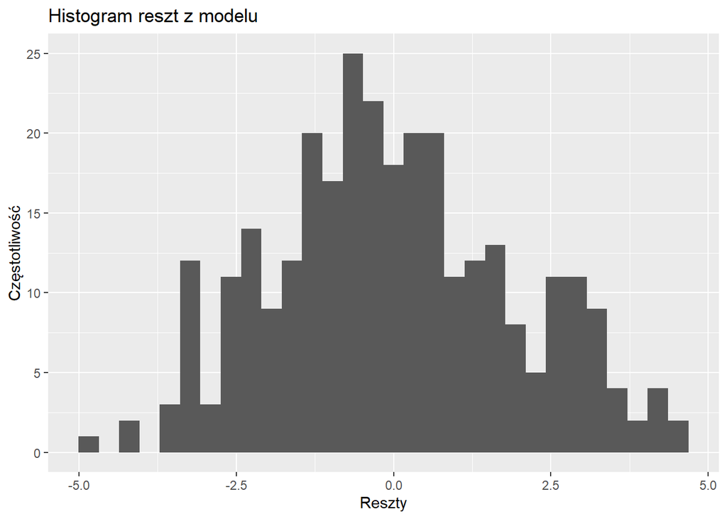

```r
ggplot(carseats_model_6, aes(x=.resid)) + geom_histogram(bins=30) + labs(title='Histogram reszt z modelu', x='Reszty', y='Częstotliwość')
```

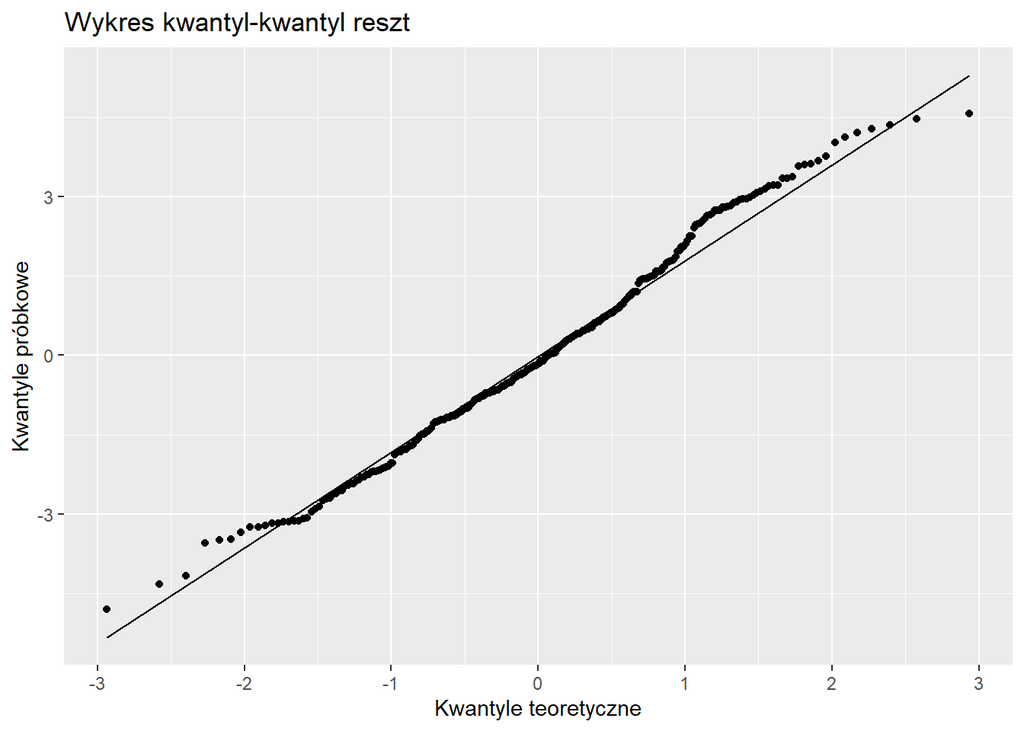

```r
ggplot(carseats_model_6, aes(sample=.resid)) + geom_qq() + geom_qq_line() + labs(title='Wykres kwantyl-kwantyl reszt', x='Kwantyle teoretyczne', y='Kwantyle próbkowe')
```

Nasz Histogram przypomina wykres rozkładu normalnego, oraz na wykresie kwantyl-kwantyl widzimy tylko kilka odstających wartości dlatego w obu przypadkach nie odrzucamy możliwego rozkładu normalnego.

Wykonajmy jeszcze test Shapiro-Wilka

Nasza hipoteza zerowa testu: $H_0:$ Populacja ma rozkład normalny.

```r
shapiro.test(carseats_model_6$residuals)
```

```
##
##  Shapiro-Wilk normality test
##
## data:  carseats_model_6$residuals
## W = 0.98901, p-value = 0.02249
```

Spróbujemy zatem dodać kolejne zmienne do modelu

```r
carseats_model_6 <- lm(Sales ~ Price + Advertising + Age + Income + CompPrice + ShelveLoc + Urban + US ,data=Carseats_train)
summary(carseats_model_6)
```

```
##
## Call:
## lm(formula = Sales ~ Price + Advertising + Age + Income + CompPrice +
##     ShelveLoc + Urban + US, data = Carseats_train)
##
## Residuals:
##     Min      1Q  Median      3Q     Max
## -2.6630 -0.7232  0.0321  0.6384  3.3361
##
## Coefficients:
##                  Estimate Std. Error t value Pr(>|t|)
## (Intercept)      5.492340   0.561421   9.783  < 2e-16 ***
## Price           -0.096619   0.003107 -31.101  < 2e-16 ***
## Advertising      0.124755   0.011853  10.525  < 2e-16 ***
## Age             -0.047308   0.003630 -13.034  < 2e-16 ***
## Income           0.015633   0.002148   7.278 3.17e-12 ***
## CompPrice        0.093810   0.004556  20.593  < 2e-16 ***
## ShelveLocGood    4.961846   0.178214  27.842  < 2e-16 ***
## ShelveLocMedium  2.070523   0.143562  14.423  < 2e-16 ***
## UrbanYes         0.145074   0.130092   1.115   0.2657
## USYes           -0.296908   0.168816  -1.759   0.0797 .
## ---
## Signif. codes:  0 '***' 0.001 '**' 0.01 '*' 0.05 '.' 0.1 ' ' 1
##
## Residual standard error: 1.01 on 291 degrees of freedom
## Multiple R-squared:  0.8749, Adjusted R-squared:  0.871
## F-statistic: 226.2 on 9 and 291 DF,  p-value: < 2.2e-16
```

```r
model_summary(carseats_model_6, Carseats_train, Carseats_test, Carseats_train$Sales, Carseats_test$Sales)
```

```
## Charakterystyki 'train'
## RMSE wynosi: 0.9935241
## MAE wynosi: 0.8015572
## MAPE wynosi: Inf %
## ------------------------------------
## Charakterystyki 'test'
## RMSE wynosi: 1.053827
## MAE wynosi: 0.856469
## MAPE wynosi: 15.30233 %
```

Widzimy, że zmienne Urban i US nie są istotne w naszym modelu, zatem odrzucamy je.

Spróbujemy zatem podzielić zbiór

```r
set.seed(800)
Carseats_train$ShelveLoc <- as_factor(Carseats_train$ShelveLoc)
Carseats_test$ShelveLoc <- as_factor(Carseats_test$ShelveLoc)
Carseats_train_ohc <- Carseats_train %>% dplyr::mutate(ShelveGood = ifelse(ShelveLoc=='Good',1,0)) %>% dplyr::mutate(ShelveMed = ifelse(ShelveLoc=='Medium',1,0)) %>%     dplyr::mutate(ShelveBad = ifelse(ShelveLoc=='Bad',1,0))
Carseats_test_ohc <- Carseats_test %>% dplyr::mutate(ShelveGood = ifelse(ShelveLoc=='Good',1,0)) %>% dplyr::mutate(ShelveMed = ifelse(ShelveLoc=='Medium',1,0)) %>%     dplyr::mutate(ShelveBad = ifelse(ShelveLoc=='Bad',1,0))
head(Carseats_train_ohc)
```

|  | Sales | CompPrice | Income | Advertising | Population | Price | ShelveLoc | Age | Education | Urban | US | ShelveGood | ShelveMed | ShelveBad |
| --- | --- | --- | --- | --- | --- | --- | --- | --- | --- | --- | --- | --- | --- | --- |
| 2 | 11.22 | 111 | 48 | 16 | 260 | 83 | Good | 65 | 10 | Yes | Yes | 1 | 0 | 0 |
| 3 | 10.06 | 113 | 35 | 10 | 269 | 80 | Medium | 59 | 12 | Yes | Yes | 0 | 1 | 0 |
| 4 | 7.40 | 117 | 100 | 4 | 466 | 97 | Medium | 55 | 14 | Yes | Yes | 0 | 1 | 0 |
| 6 | 10.81 | 124 | 113 | 13 | 501 | 72 | Bad | 78 | 16 | No | Yes | 0 | 0 | 1 |
| 8 | 11.85 | 136 | 81 | 15 | 425 | 120 | Good | 67 | 10 | Yes | Yes | 1 | 0 | 0 |
| 9 | 6.54 | 132 | 110 | 0 | 108 | 124 | Medium | 76 | 10 | No | No | 0 | 1 | 0 |

```r
Carseats_ohc<- carseats %>% dplyr::mutate(ShelveGood = ifelse(ShelveLoc=='Good',1,0)) %>% dplyr::mutate(ShelveMed = ifelse(ShelveLoc=='Medium',1,0)) %>%     dplyr::mutate(ShelveBad = ifelse(ShelveLoc=='Bad',1,0))
```

```r
set.seed(800)
Carseats_train_ohc$Urban <- as_factor(Carseats_train_ohc$Urban)
Carseats_test$Urban <- as_factor(Carseats_test_ohc$Urban)
Carseats_train_ohc_2 <- Carseats_train_ohc %>% dplyr::mutate(UrbanYes = ifelse(Urban=='Yes',1,0)) %>% dplyr::mutate(UrbanNo = ifelse(Urban=='No',1,0))

Carseats_test_ohc_2 <- Carseats_test_ohc %>% dplyr::mutate(UrbanYes = ifelse(Urban=='Yes',1,0)) %>% dplyr::mutate(UrbanNo = ifelse(Urban=='No',1,0))
head(Carseats_train_ohc_2)
```

|  | Sales | CompPrice | Income | Advertising | Population | Price | ShelveLoc | Age | Education | Urban | US | ShelveGood | ShelveMed | ShelveBad | UrbanYes | UrbanNo |
| --- | --- | --- | --- | --- | --- | --- | --- | --- | --- | --- | --- | --- | --- | --- | --- | --- |
| 2 | 11.22 | 111 | 48 | 16 | 260 | 83 | Good | 65 | 10 | Yes | Yes | 1 | 0 | 0 | 1 | 0 |
| 3 | 10.06 | 113 | 35 | 10 | 269 | 80 | Medium | 59 | 12 | Yes | Yes | 0 | 1 | 0 | 1 | 0 |
| 4 | 7.40 | 117 | 100 | 4 | 466 | 97 | Medium | 55 | 14 | Yes | Yes | 0 | 1 | 0 | 1 | 0 |
| 6 | 10.81 | 124 | 113 | 13 | 501 | 72 | Bad | 78 | 16 | No | Yes | 0 | 0 | 1 | 0 | 1 |
| 8 | 11.85 | 136 | 81 | 15 | 425 | 120 | Good | 67 | 10 | Yes | Yes | 1 | 0 | 0 | 1 | 0 |
| 9 | 6.54 | 132 | 110 | 0 | 108 | 124 | Medium | 76 | 10 | No | No | 0 | 1 | 0 | 0 | 1 |

```r
Carseats_ohc_2<- Carseats_ohc %>% dplyr::mutate(UrbanYes = ifelse(Urban=='Yes',1,0)) %>% dplyr::mutate(UrbanNo = ifelse(Urban=='No',1,0))
```

```r
set.seed(800)
Carseats_train_ohc_2$Urban <- as_factor(Carseats_train_ohc_2$US)
Carseats_test$US <- as_factor(Carseats_test_ohc_2$US)
Carseats_train_ohc_3 <- Carseats_train_ohc_2 %>% dplyr::mutate(USYes = ifelse(US=='Yes',1,0)) %>% dplyr::mutate(USNo = ifelse(US=='No',1,0))

Carseats_test_ohc_3 <- Carseats_test_ohc_2 %>% dplyr::mutate(USYes = ifelse(US=='Yes',1,0)) %>% dplyr::mutate(USNo = ifelse(US=='No',1,0))
head(Carseats_train_ohc_3)
```

|  | Sales | CompPrice | Income | Advertising | Population | Price | ShelveLoc | Age | Education | Urban | US | ShelveGood | ShelveMed | ShelveBad | UrbanYes | UrbanNo | USYes | USNo |
| --- | --- | --- | --- | --- | --- | --- | --- | --- | --- | --- | --- | --- | --- | --- | --- | --- | --- | --- |
| 2 | 11.22 | 111 | 48 | 16 | 260 | 83 | Good | 65 | 10 | Yes | Yes | 1 | 0 | 0 | 1 | 0 | 1 | 0 |
| 3 | 10.06 | 113 | 35 | 10 | 269 | 80 | Medium | 59 | 12 | Yes | Yes | 0 | 1 | 0 | 1 | 0 | 1 | 0 |
| 4 | 7.40 | 117 | 100 | 4 | 466 | 97 | Medium | 55 | 14 | Yes | Yes | 0 | 1 | 0 | 1 | 0 | 1 | 0 |
| 6 | 10.81 | 124 | 113 | 13 | 501 | 72 | Bad | 78 | 16 | Yes | Yes | 0 | 0 | 1 | 0 | 1 | 1 | 0 |
| 8 | 11.85 | 136 | 81 | 15 | 425 | 120 | Good | 67 | 10 | Yes | Yes | 1 | 0 | 0 | 1 | 0 | 1 | 0 |
| 9 | 6.54 | 132 | 110 | 0 | 108 | 124 | Medium | 76 | 10 | No | No | 0 | 1 | 0 | 0 | 1 | 0 | 1 |

```r
Carseats_ohc_3<- Carseats_ohc_2 %>% dplyr::mutate(USYes = ifelse(US=='Yes',1,0)) %>% dplyr::mutate(USNo = ifelse(US=='No',1,0))
```

Spróbujmy stworzyć model z podzielonymi danymi

```r
carseats_model_7 <- lm(Sales ~ Price + Advertising + Age + Income + CompPrice + ShelveGood + ShelveMed + ShelveBad ,data=Carseats_train_ohc_3)
summary(carseats_model_7)
```

```
##
## Call:
## lm(formula = Sales ~ Price + Advertising + Age + Income + CompPrice +
##     ShelveGood + ShelveMed + ShelveBad, data = Carseats_train_ohc_3)
##
## Residuals:
##     Min      1Q  Median      3Q     Max
## -2.6421 -0.7685  0.0240  0.6485  3.2345
##
## Coefficients: (1 not defined because of singularities)
##              Estimate Std. Error t value Pr(>|t|)
## (Intercept)  5.497001   0.562210   9.777  < 2e-16 ***
## Price       -0.096677   0.003116 -31.024  < 2e-16 ***
## Advertising  0.111163   0.008921  12.462  < 2e-16 ***
## Age         -0.047090   0.003631 -12.969  < 2e-16 ***
## Income       0.015196   0.002133   7.125 8.09e-12 ***
## CompPrice    0.094024   0.004557  20.633  < 2e-16 ***
## ShelveGood   4.936180   0.178059  27.722  < 2e-16 ***
## ShelveMed    2.063021   0.143676  14.359  < 2e-16 ***
## ShelveBad          NA         NA      NA       NA
## ---
## Signif. codes:  0 '***' 0.001 '**' 0.01 '*' 0.05 '.' 0.1 ' ' 1
##
## Residual standard error: 1.014 on 293 degrees of freedom
## Multiple R-squared:  0.8732, Adjusted R-squared:  0.8702
## F-statistic: 288.4 on 7 and 293 DF,  p-value: < 2.2e-16
```

Stwórzmy, zatem ten model jeszcze raz, jednak bez zmiennej $ShelveBad$.

```r
carseats_model_8 <- lm(Sales ~ Price + Advertising + Age + Income + CompPrice+ ShelveGood + ShelveMed ,data=Carseats_train_ohc_3)
summary(carseats_model_8)
```

```
##
## Call:
## lm(formula = Sales ~ Price + Advertising + Age + Income + CompPrice +
##     ShelveGood + ShelveMed, data = Carseats_train_ohc_3)
##
## Residuals:
##     Min      1Q  Median      3Q     Max
## -2.6421 -0.7685  0.0240  0.6485  3.2345
##
## Coefficients:
##              Estimate Std. Error t value Pr(>|t|)
## (Intercept)  5.497001   0.562210   9.777  < 2e-16 ***
## Price       -0.096677   0.003116 -31.024  < 2e-16 ***
## Advertising  0.111163   0.008921  12.462  < 2e-16 ***
## Age         -0.047090   0.003631 -12.969  < 2e-16 ***
## Income       0.015196   0.002133   7.125 8.09e-12 ***
## CompPrice    0.094024   0.004557  20.633  < 2e-16 ***
## ShelveGood   4.936180   0.178059  27.722  < 2e-16 ***
## ShelveMed    2.063021   0.143676  14.359  < 2e-16 ***
## ---
## Signif. codes:  0 '***' 0.001 '**' 0.01 '*' 0.05 '.' 0.1 ' ' 1
##
## Residual standard error: 1.014 on 293 degrees of freedom
## Multiple R-squared:  0.8732, Adjusted R-squared:  0.8702
## F-statistic: 288.4 on 7 and 293 DF,  p-value: < 2.2e-16
```

Nasz model wyjaśnia znaczną część zmienności danych sprzedażowych, czyli około $87%$ . Oznacza to, że zmienne w modelu są w stanie wytłumaczyć dużą część różnic w sprzedaży. Wszystkie nasze zmienne w modelu $'Price', 'Advertising', 'Age', 'Income', 'CompPrice', 'ShelveGood', 'ShelveMed'$ wydają się być istotne statystycznie ponieważ $p-value < 0.05$, co sugeruje, że każdy z tych czynników ma wpływ na sprzedaż. $RSE$ jest niska, bo około $1.014$, co sugeruje, że model dobrze dopasowuje się do danych. Oznacza to, że przewidywane wartości sprzedaży są blisko rzeczywistych wartości sprzedaży.

Zatem jest to najlepszy model z wszystkich dotychczas, skupimy się na nim i dla niego zobaczymy czy spełnia założenia modelu liniowej regresji.

Obliczmy charakterystyki liczbowe:

```r
model_summary(carseats_model_8, Carseats_train_ohc_3, Carseats_test_ohc_3, Carseats_train_ohc_3$Sales, Carseats_test_ohc_3$Sales)
```

```
## Charakterystyki 'train'
## RMSE wynosi: 1.00016
## MAE wynosi: 0.7998348
## MAPE wynosi: Inf %
## ------------------------------------
## Charakterystyki 'test'
## RMSE wynosi: 1.044781
## MAE wynosi: 0.8472517
## MAPE wynosi: 15.25903 %
```

Zajmiemy się teraz założeniami modelu

### Założenie 1: Niezależność liniowa:

Sprawdzamy czy zmienne objaśniające w naszym modelu są liniowo niezależne.

```r
carseats_cormat<- round(cor(Carseats_train_ohc_3[,c(3,4,6,8,12,13)]),2)
carseats_cormat
```

```
##             Income Advertising Price   Age ShelveGood ShelveMed
## Income        1.00        0.09 -0.09  0.01      -0.04     -0.02
## Advertising   0.09        1.00  0.04 -0.02       0.10     -0.04
## Price        -0.09        0.04  1.00 -0.10       0.10     -0.01
## Age           0.01       -0.02 -0.10  1.00      -0.05      0.07
## ShelveGood   -0.04        0.10  0.10 -0.05       1.00     -0.57
## ShelveMed    -0.02       -0.04 -0.01  0.07      -0.57      1.00
```

### Założenie 2: Rozkład reszt

Sprawdzimy założenie drugie za pomocą histogramu, wykresu kwantyl-kwantyl oraz testu Shapiro-Wilka.

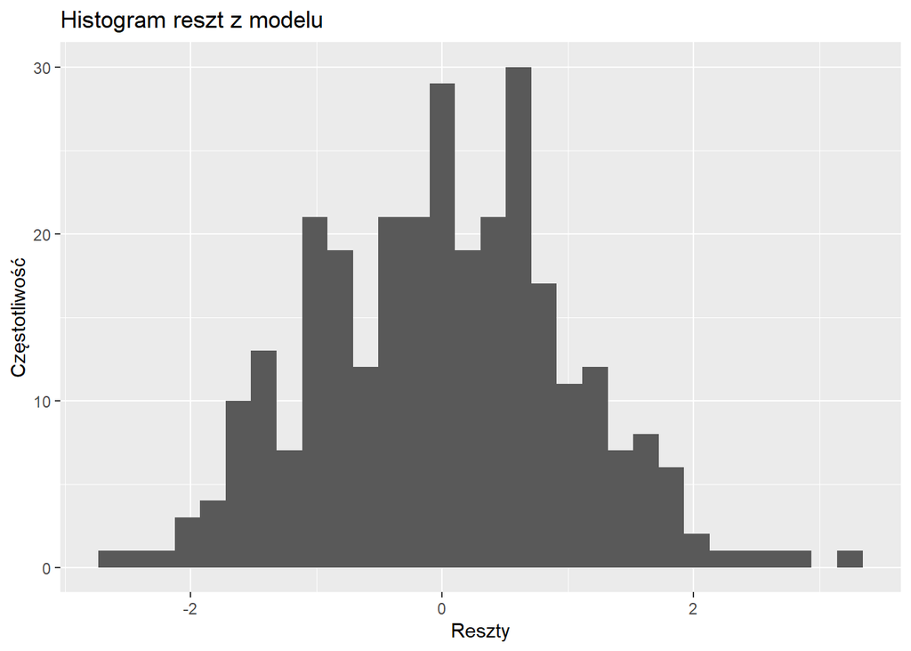

```r
ggplot(carseats_model_8, aes(x=.resid)) + geom_histogram(bins=30) + labs(title='Histogram reszt z modelu', x='Reszty', y='Częstotliwość')
```

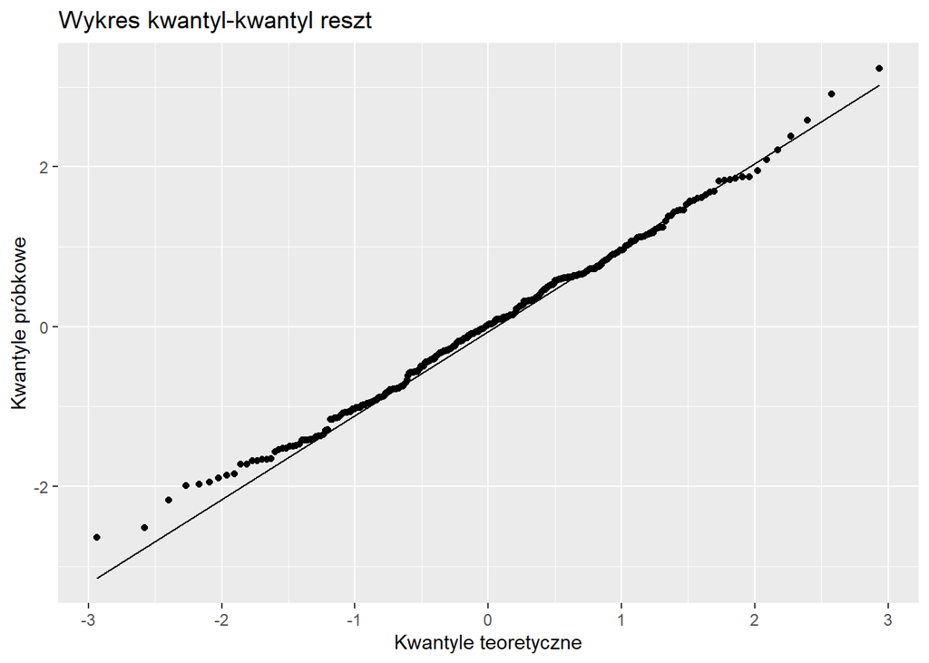

```r
ggplot(carseats_model_8, aes(sample=.resid)) + geom_qq() + geom_qq_line() + labs(title='Wykres kwantyl-kwantyl reszt', x='Kwantyle teoretyczne', y='Kwantyle próbkowe')
```

Nasz Histogram przypomina wykres rozkładu normalnego, oraz na wykresie kwantyl-kwantyl widzimy tylko kilka odstających wartości dlatego w obu przypadkach nie odrzucamy możliwego rozkładu normalnego.

Wykonajmy jeszcze test Shapiro-Wilka

Nasza hipoteza zerowa testu: $H_0:$ Populacja ma rozkład normalny.

```r
shapiro.test(carseats_model_8$residuals)
```

```
##
##  Shapiro-Wilk normality test
##
## data:  carseats_model_8$residuals
## W = 0.99624, p-value = 0.6963
```

Wartość $p-value$ jest wysoka, większa niż typowy poziom istotności $0.05$, co sugeruje, że nie ma wystarczająco mocnych dowodów na odrzucenie hipotezy zerowej, czyli hipotezy o normalności rozkładu reszt. Zatem reszty mają rozkład normalny Wartość statystyki testowej jest również wysoka, co dodatkowo sugeruje, że reszty mogą być rozłożone symetrycznie wokół średniej.

### Założenie 3: Zerowa średnia reszt:

Do zbadania trzeciego założenia wykonamy test t-studenta.

```r
t.test(carseats_model_8$residuals)
```

```
##
##  One Sample t-test
##
## data:  carseats_model_8$residuals
## t = -1.0014e-15, df = 300, p-value = 1
## alternative hypothesis: true mean is not equal to 0
## 95 percent confidence interval:
##  -0.1136351  0.1136351
## sample estimates:
##     mean of x
## -5.782686e-17
```

Z wyniku testu t-studenta możemy wyczytać, że wartość średnia reszt jest bliska zeru, co sugeruje nam, że nie różni się ona istotnie od zera. Zatem trzeci warunek również jest spełniony.

Narysujemy sobie teraz wykres “Residuals vs Fitted”, by zobaczyć czy nasza średnia jest zerowa oraz czy nasze reszty są niezależne.

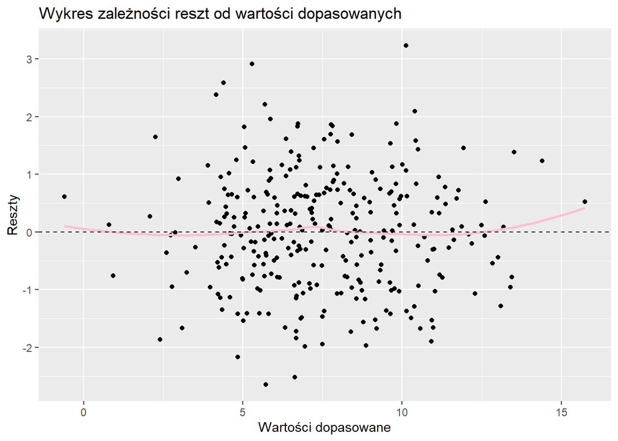

```r
ggplot(carseats_model_8, aes(.fitted, .resid)) + geom_point() + stat_smooth(method='loess', formula=y~x, se=FALSE, color='pink') +
  geom_hline(yintercept=0, linetype='dashed', color='black') + labs(title='Wykres zależności reszt od wartości dopasowanych', x='Wartości dopasowane',
                                                                  y='Reszty')
```

Nie mamy wielu odchyleń, dlatego średnia faktycznie będzie zerowa.

### Założenie 4: Niezależność reszt:

Aby sprawdzić niezależność reszt wykonujemy test Durbina Watsona.

```r
library(lmtest)
lmtest::dwtest(carseats_model_8)
```

```
##
##  Durbin-Watson test
##
## data:  carseats_model_8
## DW = 1.8544, p-value = 0.1019
## alternative hypothesis: true autocorrelation is greater than 0
```

Wartość $p-value$ jest równa $0.1019$ czyli jest większa od $\alpha=0.05$ zatem nie mamy dowodów, by odrzucać hipotezę o niezależności reszt. Bierzemy się więc za kolejne założenie.

### Założenie 5: Homoskedastyczność.

Aby zbadać homoskedastyczność rysujemy wykres “Scale-Location”.

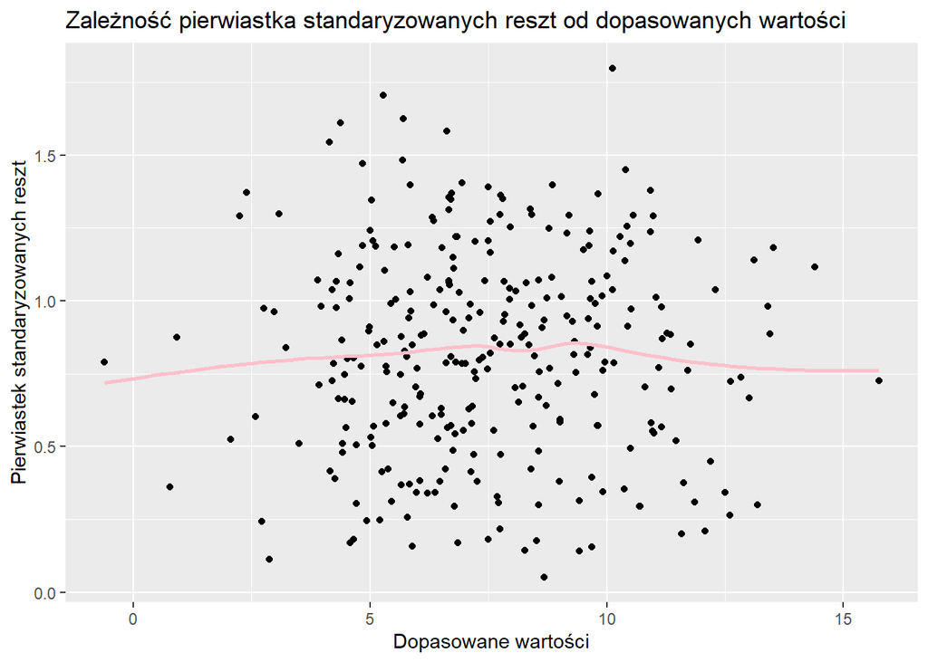

```r
ggplot(carseats_model_8, aes(.fitted, sqrt(abs(.stdresid)))) + geom_point() + stat_smooth(method='loess', formula=y~x, se=FALSE, color='pink') +
  labs(title='Zależność pierwiastka standaryzowanych reszt od dopasowanych wartości', x='Dopasowane wartości', y='Pierwiastek standaryzowanych reszt')
```

Dane faktycznie są rozproszone losowo względem prostej. Wykonujemy zatem test Breuscha-Pagana.

```r
lmtest::bptest(carseats_model_8)
```

```
##
##  studentized Breusch-Pagan test
##
## data:  carseats_model_8
## BP = 8.5456, df = 7, p-value = 0.2869
```

Widzimy, że wartość $p-value$ wynosi $0.2869$ co oznacza że nie mamy wystarczająco silnych dowodów na odrzucenie hipotezy zerowej o homoskedastyczności. Zatem test potwierdza, że zachodzi homoskedastyczność reszt.

Sprawdźmy za pomocą dźwigni oraz odległością Cooka, czy w naszym modelu pojawiają się obserwacje wpływowe, które mogłyby zmieniać jego postać.

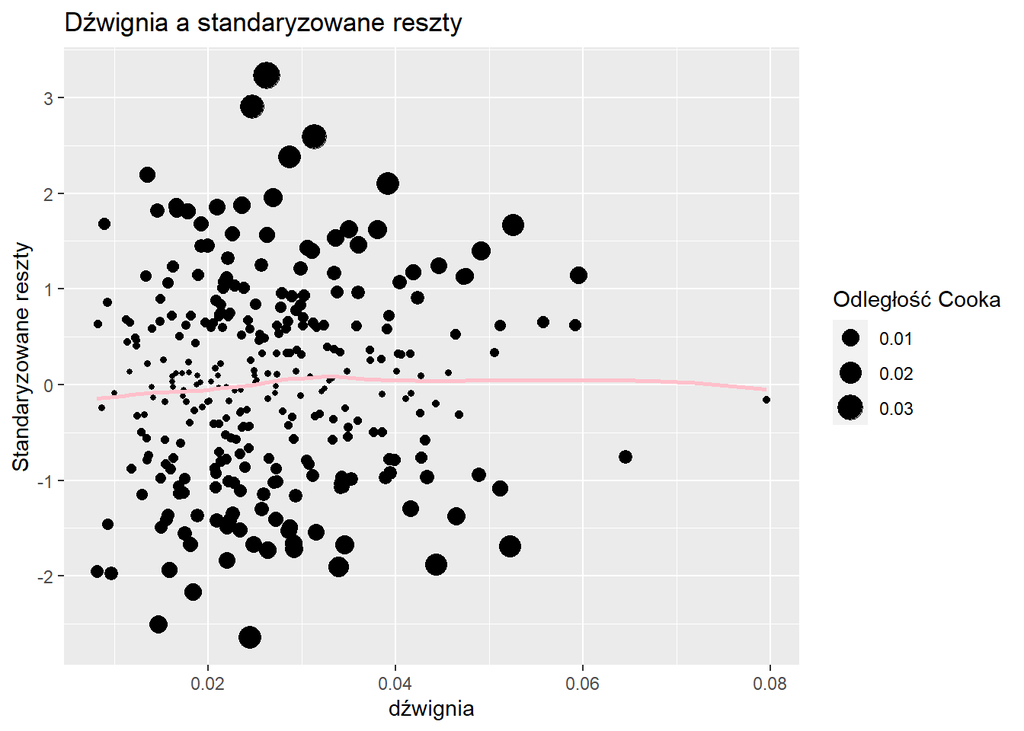

```r
ggplot(carseats_model_8, aes(.hat, .stdresid)) + geom_point(aes(size=.cooksd)) + stat_smooth(method='loess', formula=y~x, se=FALSE,color='pink') + labs(title='Dźwignia a standaryzowane reszty', x='dźwignia', y='Standaryzowane reszty', size='Odległość Cooka')
```

Widzimy, że odległość Cooka podąża za trendem naszego modelu. Duże wartości sugerują, że obserwacje znacząco wpływają na oszacowania parametrów regresji i ich usunięcie mogłoby zmienić strukturę modelu. Dlatego wyrzucamy obserwacje o pewnej określonej wartości odległości Cooka.

```r
set.seed(800)
Carseats_train_ohc_3 <- Carseats_train_ohc_3 %>% mutate(cook_D =unlist(cooks.distance(carseats_model_8))) %>% dplyr::filter(cook_D <= mean(cook_D))
Carseats_train_ohc_3
```

|  | Sales | CompPrice | Income | Advertising | Population | Price | ShelveLoc | Age | Education | Urban | US | ShelveGood | ShelveMed | ShelveBad | UrbanYes | UrbanNo | USYes | USNo | cook_D |
| --- | --- | --- | --- | --- | --- | --- | --- | --- | --- | --- | --- | --- | --- | --- | --- | --- | --- | --- | --- |
| 3 | 10.06 | 113 | 35 | 10 | 269 | 80 | Medium | 59 | 12 | Yes | Yes | 0 | 1 | 0 | 1 | 0 | 1 | 0 | 1.487936e-03 |
| 4 | 7.40 | 117 | 100 | 4 | 466 | 97 | Medium | 55 | 14 | Yes | Yes | 0 | 1 | 0 | 1 | 0 | 1 | 0 | 2.163317e-03 |
| 8 | 11.85 | 136 | 81 | 15 | 425 | 120 | Good | 67 | 10 | Yes | Yes | 1 | 0 | 0 | 1 | 0 | 1 | 0 | 7.909161e-04 |
| 9 | 6.54 | 132 | 110 | 0 | 108 | 124 | Medium | 76 | 10 | No | No | 0 | 1 | 0 | 0 | 1 | 0 | 1 | 7.014431e-04 |
| 11 | 9.01 | 121 | 78 | 9 | 150 | 100 | Bad | 26 | 10 | Yes | Yes | 0 | 0 | 1 | 0 | 1 | 1 | 0 | 2.274725e-03 |
| 12 | 11.96 | 117 | 94 | 4 | 503 | 94 | Good | 50 | 13 | Yes | Yes | 1 | 0 | 0 | 1 | 0 | 1 | 0 | 2.883602e-05 |
| 18 | 12.29 | 147 | 74 | 13 | 251 | 131 | Good | 52 | 10 | Yes | Yes | 1 | 0 | 0 | 1 | 0 | 1 | 0 | 1.047119e-03 |
| 21 | 6.41 | 125 | 90 | 2 | 367 | 131 | Medium | 35 | 18 | Yes | Yes | 0 | 1 | 0 | 1 | 0 | 1 | 0 | 7.213868e-05 |
| 22 | 12.13 | 134 | 29 | 12 | 239 | 109 | Good | 62 | 18 | Yes | Yes | 1 | 0 | 0 | 0 | 1 | 1 | 0 | 2.305515e-03 |
| 23 | 5.08 | 128 | 46 | 6 | 497 | 138 | Medium | 42 | 13 | No | No | 0 | 1 | 0 | 1 | 0 | 0 | 1 | 5.301982e-04 |

[output cut: 199 more lines]

Sprawdźmy jak teraz działa model

```r
carseats_model_8 <- lm(Sales ~ Price + Advertising + Age + Income + CompPrice+ ShelveGood + ShelveMed ,data=Carseats_train_ohc_3)
summary(carseats_model_8)
```

```
##
## Call:
## lm(formula = Sales ~ Price + Advertising + Age + Income + CompPrice +
##     ShelveGood + ShelveMed, data = Carseats_train_ohc_3)
##
## Residuals:
##      Min       1Q   Median       3Q      Max
## -1.49773 -0.42375 -0.02133  0.44621  1.68961
##
## Coefficients:
##              Estimate Std. Error t value Pr(>|t|)
## (Intercept)  6.026310   0.411012   14.66   <2e-16 ***
## Price       -0.094339   0.002260  -41.75   <2e-16 ***
## Advertising  0.113086   0.006452   17.53   <2e-16 ***
## Age         -0.048742   0.002705  -18.02   <2e-16 ***
## Income       0.015590   0.001549   10.07   <2e-16 ***
## CompPrice    0.087825   0.003237   27.13   <2e-16 ***
## ShelveGood   5.124045   0.133412   38.41   <2e-16 ***
## ShelveMed    2.117512   0.104341   20.29   <2e-16 ***
## ---
## Signif. codes:  0 '***' 0.001 '**' 0.01 '*' 0.05 '.' 0.1 ' ' 1
##
## Residual standard error: 0.5921 on 201 degrees of freedom
## Multiple R-squared:  0.954,  Adjusted R-squared:  0.9524
## F-statistic: 596.1 on 7 and 201 DF,  p-value: < 2.2e-16
```

Wartość $p-value < 0.05$ co oznacza że model jest statystycznie znaczący. Współczynnik determinacji $R^2$ wynoszący $0.954$ wskazuje, że model wyjaśnia około $95.4%$ zmienności wartości sprzedaży. Jest to najlepszy wynik jaki otrzymaliśmy.

Sprawdźmy teraz wartości na zbiorze testowym.

```r
set.seed(800)
carseats_model_8_testowy <- predict(carseats_model_8, Carseats_test_ohc_3)
```

```r
set.seed(800)
MAPE(Carseats_train_ohc_3$Sales, predict(carseats_model_8, Carseats_train_ohc_3))
```

```
## [1] Inf
```

```r
RMSE(Carseats_train_ohc_3$Sales, predict(carseats_model_8, Carseats_train_ohc_3))
```

```
## [1] 0.5806255
```

```r
sqrt(mean(carseats_model_8$residuals^2))
```

```
## [1] 0.5806255
```

```r
MAPE(Carseats_test_ohc_3$Sales, predict(carseats_model_8, Carseats_test_ohc_3))
```

```
## [1] 15.38463
```

```r
RMSE(Carseats_test_ohc_3$Sales, predict(carseats_model_8, Carseats_test_ohc_3))
```

```
## [1] 1.049266
```

Zredukujmy jeszcze obserwacje o dużej odległości Cooka. wtedy nasze dane wyglądają następująco:

```r
Carseats_train_5 <- Carseats_train_ohc_3 %>% mutate(cooks_D = cooks.distance(carseats_model_8)) %>% filter(cooks_D <= 3*mean(cooks_D))
Carseats_train_5
```

|  | Sales | CompPrice | Income | Advertising | Population | Price | ShelveLoc | Age | Education | Urban | US | ShelveGood | ShelveMed | ShelveBad | UrbanYes | UrbanNo | USYes | USNo | cook_D | cooks_D |
| --- | --- | --- | --- | --- | --- | --- | --- | --- | --- | --- | --- | --- | --- | --- | --- | --- | --- | --- | --- | --- |
| 3 | 10.06 | 113 | 35 | 10 | 269 | 80 | Medium | 59 | 12 | Yes | Yes | 0 | 1 | 0 | 1 | 0 | 1 | 0 | 1.487936e-03 | 7.381100e-03 |
| 4 | 7.40 | 117 | 100 | 4 | 466 | 97 | Medium | 55 | 14 | Yes | Yes | 0 | 1 | 0 | 1 | 0 | 1 | 0 | 2.163317e-03 | 9.861159e-03 |
| 8 | 11.85 | 136 | 81 | 15 | 425 | 120 | Good | 67 | 10 | Yes | Yes | 1 | 0 | 0 | 1 | 0 | 1 | 0 | 7.909161e-04 | 2.456192e-03 |
| 9 | 6.54 | 132 | 110 | 0 | 108 | 124 | Medium | 76 | 10 | No | No | 0 | 1 | 0 | 0 | 1 | 0 | 1 | 7.014431e-04 | 3.245882e-03 |
| 11 | 9.01 | 121 | 78 | 9 | 150 | 100 | Bad | 26 | 10 | Yes | Yes | 0 | 0 | 1 | 0 | 1 | 1 | 0 | 2.274725e-03 | 9.950970e-03 |
| 12 | 11.96 | 117 | 94 | 4 | 503 | 94 | Good | 50 | 13 | Yes | Yes | 1 | 0 | 0 | 1 | 0 | 1 | 0 | 2.883602e-05 | 1.013375e-04 |
| 18 | 12.29 | 147 | 74 | 13 | 251 | 131 | Good | 52 | 10 | Yes | Yes | 1 | 0 | 0 | 1 | 0 | 1 | 0 | 1.047119e-03 | 3.590230e-03 |
| 21 | 6.41 | 125 | 90 | 2 | 367 | 131 | Medium | 35 | 18 | Yes | Yes | 0 | 1 | 0 | 1 | 0 | 1 | 0 | 7.213868e-05 | 7.853049e-04 |
| 22 | 12.13 | 134 | 29 | 12 | 239 | 109 | Good | 62 | 18 | Yes | Yes | 1 | 0 | 0 | 0 | 1 | 1 | 0 | 2.305515e-03 | 8.960650e-03 |
| 23 | 5.08 | 128 | 46 | 6 | 497 | 138 | Medium | 42 | 13 | No | No | 0 | 1 | 0 | 1 | 0 | 0 | 1 | 5.301982e-04 | 2.876210e-03 |

[output cut: 184 more lines]

W takim wypadku nasz model ostatecznie wygląda następująco:

```r
carseats_model_8 <- lm(Sales ~ Price + Advertising + Age + Income + CompPrice+ ShelveGood + ShelveMed ,data=Carseats_train_5)
summary(carseats_model_8)
```

```
##
## Call:
## lm(formula = Sales ~ Price + Advertising + Age + Income + CompPrice +
##     ShelveGood + ShelveMed, data = Carseats_train_5)
##
## Residuals:
##      Min       1Q   Median       3Q      Max
## -1.50579 -0.36940 -0.01962  0.40758  1.15230
##
## Coefficients:
##              Estimate Std. Error t value Pr(>|t|)
## (Intercept)  6.284062   0.378922   16.58   <2e-16 ***
## Price       -0.093618   0.002088  -44.84   <2e-16 ***
## Advertising  0.118441   0.005911   20.04   <2e-16 ***
## Age         -0.049195   0.002491  -19.75   <2e-16 ***
## Income       0.016316   0.001427   11.44   <2e-16 ***
## CompPrice    0.084359   0.003074   27.45   <2e-16 ***
## ShelveGood   5.175996   0.121484   42.61   <2e-16 ***
## ShelveMed    2.159140   0.096730   22.32   <2e-16 ***
## ---
## Signif. codes:  0 '***' 0.001 '**' 0.01 '*' 0.05 '.' 0.1 ' ' 1
##
## Residual standard error: 0.525 on 186 degrees of freedom
## Multiple R-squared:  0.9629, Adjusted R-squared:  0.9615
## F-statistic: 689.2 on 7 and 186 DF,  p-value: < 2.2e-16
```

```r
set.seed(800)
MAPE(Carseats_train_5$Sales, predict(carseats_model_8, Carseats_train_5))
```

```
## [1] Inf
```

```r
RMSE(Carseats_train_5$Sales, predict(carseats_model_8, Carseats_train_5))
```

```
## [1] 0.5140985
```

```r
sqrt(mean(carseats_model_8$residuals^2))
```

```
## [1] 0.5140985
```

```r
MAPE(Carseats_test_ohc_3$Sales, predict(carseats_model_8, Carseats_test_ohc_3))
```

```
## [1] 15.16295
```

```r
RMSE(Carseats_test_ohc_3$Sales, predict(carseats_model_8, Carseats_test_ohc_3))
```

```
## [1] 1.049777
```

Zobaczmy jeszcze jak wygląda nasz model

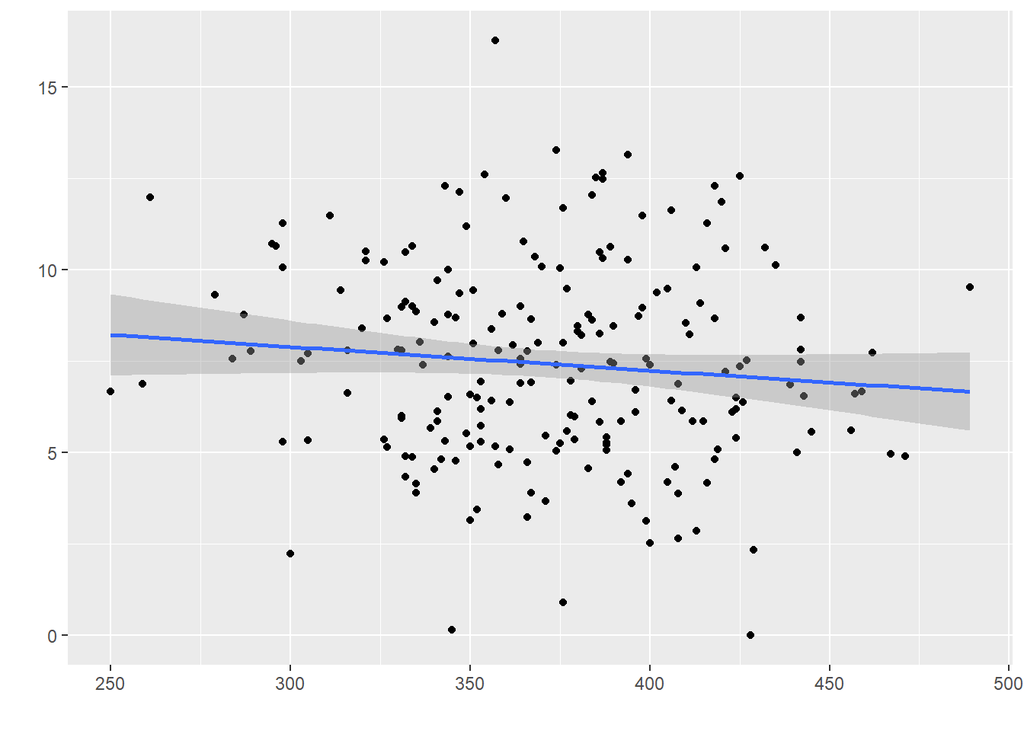

```r
ggplot(Carseats_train_ohc_3, aes(x=Price + Advertising + Age + Income + CompPrice + ShelveGood + ShelveMed, y=Sales)) + geom_point() + stat_smooth(method='lm', formula=y~x) + labs(x='', y='')
```

Podsumowując model carseats_model_8 jak widzimy jest najlepszym ze wszystkich które stworzyliśmy, wszystkie założenia zostały spełnione. Wszystkie zmienne których użyliśmy, czyli $price, advertising, age, income, compPrice, shelveGood, shelveMed$ mają na niego istotny wpływ

## Porównanie

Możemy również zobaczyć, że w przypadku modelu regresji wielorakiej błąd standardowy jest zdecydowanie niższy, co potwierdza, że model ten jest zwyczajnie bardziej precyzyjny i lepiej dopasowany do danych treningowych w porównaniu do modelu liniowego.

Co ciekawe nasz model regresji wielorakiej pomimo dużo większej ilości zmiennych $'Price' , 'Advertising', 'Age', 'Income', 'CompPrice','ShelveGood','ShelveMed'$ wciąż osiąga lepszą jakość dopasowania.

Można powiedzieć, że model regresji wielorakiej ze względu na wyższą precyzję, uwzględnianie szerszego zakresu czynników jest bardziej adekwatny do prognozowania sprzedaży w porównaniu do modelu regresji liniowej.